# stat6280

yue wu

01 19, 2018

(1).
$$E(aX+b)=\int (aX+b) f(X) dX=a (\int X f(X) dX) + b=a E(X) + b$$

(2).
$$\begin{aligned}
Cov(aX+Z,bY) &=E((aX+Z-aE(X)-E(Z))(bY-bE(Y)))\\
&=E(abXY-abXE(Y)+bYZ-bZE(Y)-abE(X)Y+abE(X)E(Y)-bYE(Z)+bE(Y)E(Z))\\
&=abE(XY)-abE(X)E(Y)+bE(YZ)-bE(Y)E(Z)-abE(X)E(Y)+abE(X)E(Y)-bE(Z)E(Y)+bE(Z)E(Y) \\
&=abE(XY)-abE(X)E(Y)+bE(YZ)-bE(Y)E(Z) \\
&=ab Cov(X,Y) + bCov(Z,Y)
\end{aligned}$$

(3).
$$\begin{aligned}
Var(aX+bY) &=Cov(aX+bY,aX+bY) \\
&=a^2 Cov(X,X)+b^2 Cov(Y,Y)+2ab Cov(X,Y) \\
&=a^2 Var(X)+b^2 Var(Y)+2ab Cov(X,Y)
\end{aligned}$$

$\gamma_X(3)=0.7$ $Cov(X_t,X_{t \pm 3})=0.7$ the covariance between $X_t$ and $X_s$ with $|lag|=3$ is 0.7

$\phi_{33}=0$ $Corr(X_t,X_{t - 3}|X_{t-1},X_{t-2})=0$ hold $X_{t-1}$ and $X_{t-2}$ constant, the correlation between $X_t$ and $X_{t-3}$ is 0

$X_t=Z_t+0.3Z_{t-1}-0.4Z_{t-2}$ $Z_t \sim^{iid} N(0,\sigma^2)$

$E(X_t)=E(Z_t)+0.3E(Z_{t-1})-0.4E(Z_{t-2})=0$ The expectation of $X_t$ is constant.

$$\begin{aligned}
Cov(X_t,X_{t-k})&=Cov(Z_t+0.3Z_{t-1}-0.4Z_{t-2},Z_{t-k}+0.3Z_{t-1-k}-0.4Z_{t-2-k}) \\
&=Cov(Z_t,Z_{t-k})+0.3Cov(Z_t,Z_{t-k-1})-0.4Cov(Z_t,Z_{t-k-2})+0.3Cov(Z_{t-1},Z_{t-k})+0.09Cov(Z_{t-1},Z_{t-k-1})-0.12Cov(Z_{t-1},Z_{t-k-2})-0.4Cov(Z_{t-2},Z_{t-k})-0.12Cov(Z_{t-2},Z_{t-k-1})+0.16Cov(Z_{t-2},Z_{t-k-2})
\end{aligned}$$

$$\begin{aligned}
&k=0, Cov(X_t,X_{t-k})=1+0.09+0.16=1.25\\
&k=\pm1, Cov(X_t,X_{t-k})=0.3-0.12=0.18\\
&k=\pm2, Cov(X_t,X_{t-k})= -0.4\\
&|k|>2, Cov(X_t,X_{t-k})=0
\end{aligned}$$

The covariance only depends on lag.

$Z_t$ is stationary

4. White noise plot

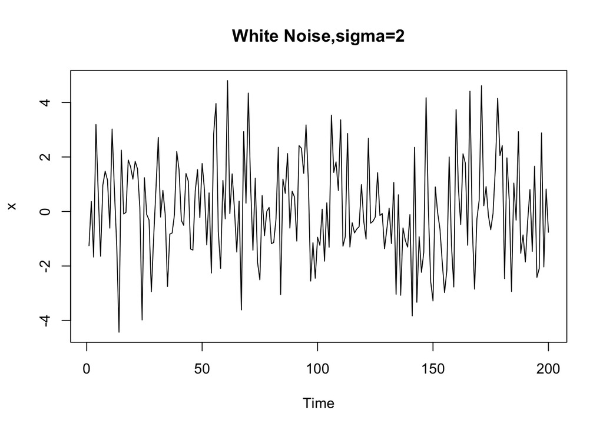

   ```r
   n=200
   set.seed(1)
   x=rnorm(n,mean=0,sd=2)
   ts.plot(x,main="White Noise,sigma=2")
   ```

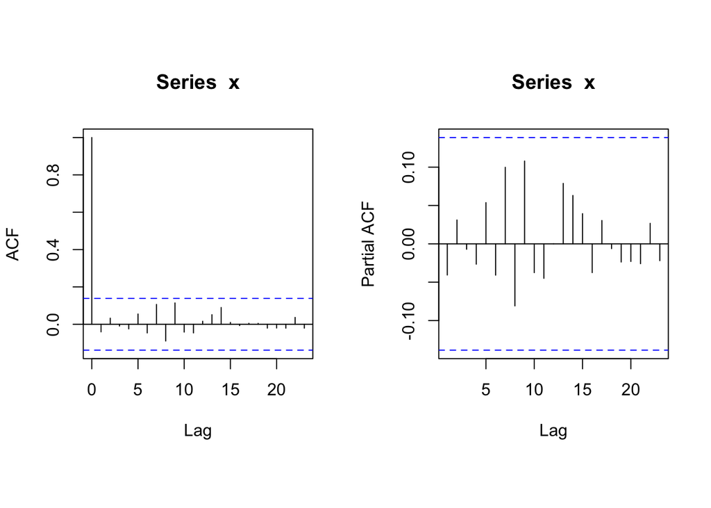

   ```r
   par(mfrow=c(1,2),pty='s')
   acf(x)
   pacf(x)
   ```

   Except lag=0, there is no significant ACF and PACF. There is little auto-correlation (dependency) between different time points.
5. random walk plot

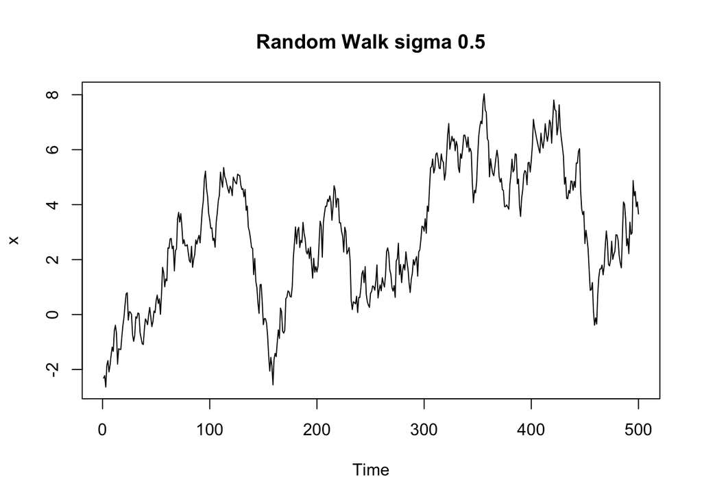

   ```r
   n=500
   inival=-2
   sigma=0.5
   gen.rw<-function(n,init,sigma) {
     x0=init
     rnum=rnorm(n,sd=sigma)
     X=cumsum(c(x0,rnum))[-1]
     return(X)
   }
   set.seed(1)
   x=gen.rw(n,inival,sigma)
   ts.plot(x,main= "Random Walk sigma 0.5")
   ```

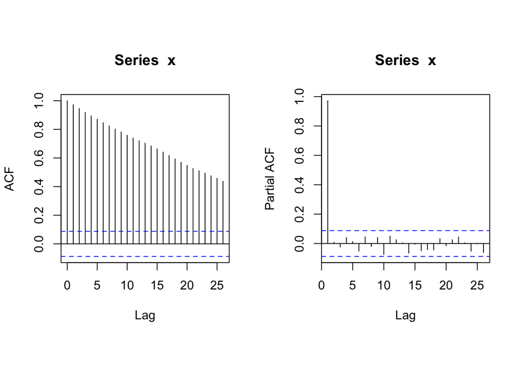

   ```r
   par(mfrow=c(1,2),pty='s')
   acf(x)
   pacf(x)
   ```

   There are significant ACF for the shown lag range and it is decreasing slowly. There is significant auto-correlation for the lag range shown.

   Except the first PACF(lag=1), there is no significant PACF. Hold $X_{t-1}$ constant, $X_t$ is not significantly correlated with $X_{t-k} \ k>1$.

The dataset “Monthly milk production: pounds per cow. Jan 62 – Dec 75” is used

(a).

The dataset contains monthly milk production (pounds) per cow from January 1962 to December 1975.

(b).

The first six data points are:

`r tab=read.table("/Users/mikeaalv/Library/Mobile Documents/com~apple~CloudDocs/working/course/stat6280/monthly-milk-production-pounds-p.tsv.csv",sep="\t",header=TRUE) tab[1:6,2]`

`## [1] 589 561 640 656 727 697`

(The last three line was manually deleted before running the R code.)

(c).

The length of the time series is:

`r dim(tab)[1]`

`## [1] 168`

(d).

`r ts.plot(tab[,2],main= "Monthly milk production")`

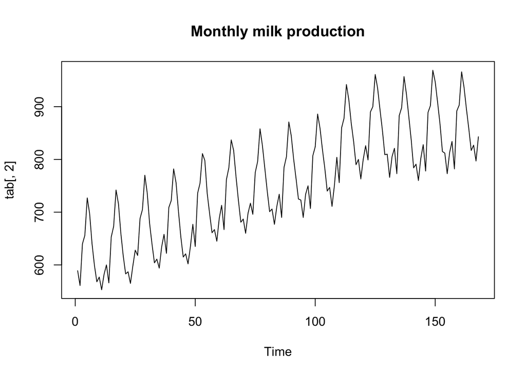

The mean of the time series is changing through time: increasing and then keep comparablly stable. The variance of the data seems to be constant. The dataset has strong seasonality and comparablly low noise.

The time series is not stationary as mean depends on time.

(e).

[figure not shown]

There is significant ACF for the shown lag range. There is significant auto-correlation between $X_t$ and $X_{t-k}$ for small k

There are only significant PACF for lag=1. Keep the $X_{t-1}$ constant, $X_{t}$ is not correlated with $X_{t-k} \ k > 1$